## Data Manipulation With `tidyEdSurvey`

EdSurvey has a companion package, `tidyEdSurvey`, designed to allow users to directly use an `edsurvey.data.frame` with common `dplyr` and `ggplot2` functions, as opposed to making a call to `getData` first. Users may also use the utility functions `attach` and `with` with an `edsurvey.data.frame`. To install, run the following code within R:

```r
install.packages("tidyEdSurvey")
```

Once the package is successfully installed, `tidyEdSurvey` can be loaded with the following command:

```r
library(tidyEdSurvey)
```

The `with` function provides a convenient shorthand for evaluating expressions on an `edsurvey.data.frame`. Here we create a boxplot of the first plausible value of math performance (`mrpcm1`) broken down by mother’s education level (`b003501`)

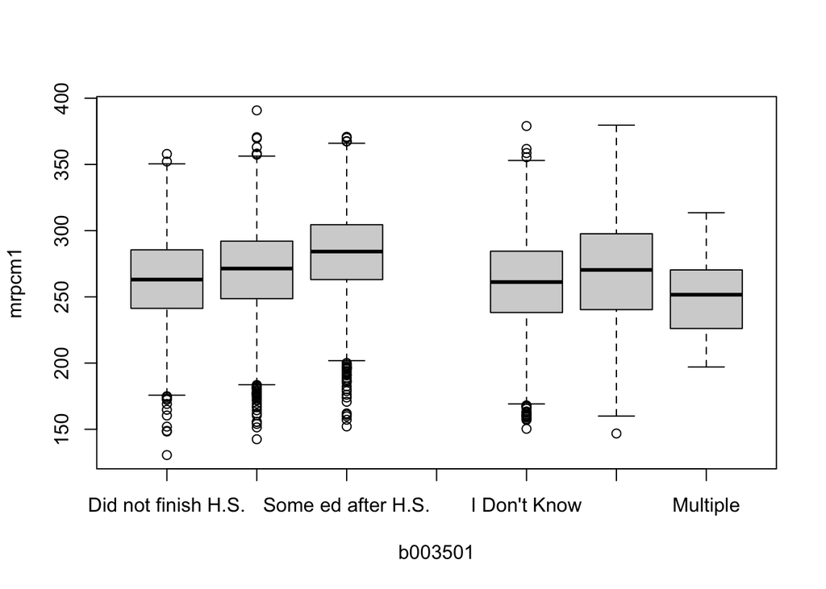

```r
with(sdf, boxplot(mrpcm1~b003501))
```

Anything that can be done with a standard `data.frame` object within `dplyr` and `ggplot2` can be done with an `edsurvey.data.frame` using `tidyEdSurvey`. There are two nuances to consider:

1. If the `select` verb is used on a weight variable (such as `origwt`), the default behavior will also return the jackknife replicate weights associated with that weight variable.
2. Any verb used with a plausible value variable (such as `algebra`) will return all of the associated plausible value columns (a total of 5 columns, in the case of the NAEP primer).

### dplyr with `edsurvey.data.frame`

All of the common `dplyr` verbs can be used with an `edsurvey.data.frame`, including: `select`, `group_by`, `filter`, `mutate`, `arrange`, and several more. We can consider an example where we filter to only female students, group by race, and get a count in each racial group.

```r
sdf %>% filter(dsex=="Female") %>% group_by(sdracem) %>% group_size()
```

```
## [1] 4977 1615 1234  384  166   53
```

We can also use the `mutate` verb to create a proficiency variable based on the 1st set of plausible values.

```r
sdf2 <- sdf %>%
    mutate(prof = case_when(
                  between(mrpcm1, 0, 261.99) ~ "Below Basic",
                  between(mrpcm1, 262, 298.99) ~ "Basic",
                  between(mrpcm1, 299, 332.99) ~ "Proficient",
                  between(mrpcm1, 333, 1e4) ~ "Advanced"))
```

We can then summarize `mrpcm1` by proficiency level, like so:

```r
sdf2 %>%
  group_by(prof) %>%
  summarize(mrpcm1)
```

```
## # A tibble: 16,915 × 2
## # Groups:   prof [4]
##    prof     mrpcm1
##    <chr>     <dbl>
##  1 Advanced   343.
##  2 Advanced   349.
##  3 Advanced   337.
##  4 Advanced   344.
##  5 Advanced   335.
##  6 Advanced   340.
##  7 Advanced   341.
##  8 Advanced   336.
##  9 Advanced   352.
## 10 Advanced   342.
## # ℹ 16,905 more rows
```

Note this is not a summary of students’ performance level, but rather of their first plausible performance level.

### ggplot2 with `edsurvey.data.frame`

We can use `ggplot2` independently or as part of a `dplyr` pipeline to visualize our `edsurvey.data.frame`. Using the previous example where we created a variable for proficiency, we can extend the pipeline to visualize the proportion of students at each achievement level by race.

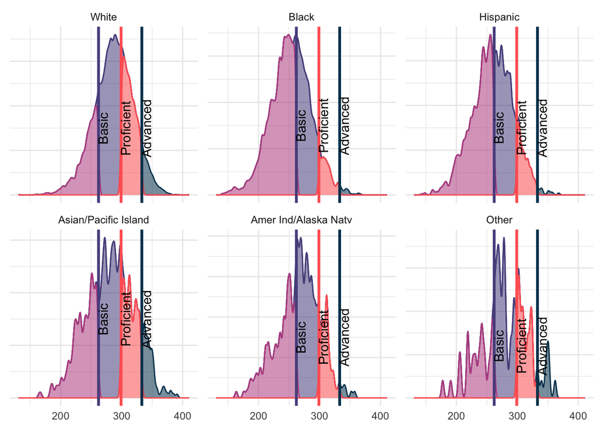

```r
sdf2 %>%
    ggplot(.,aes(x=mrpcm1,fill=prof,color=prof)) +
      facet_wrap(vars(sdracem),scales="free_y") +
      geom_density(aes(y=(..count..)/tapply(..count..,..PANEL..,sum)[..PANEL..],alpha=0.6),
               position="stack",bw=2,show.legend = FALSE) +
      scale_fill_manual(values = c("#003f5c", "#58508d", "#bc5090","#ff6361"),
                    guide = guide_none()) +
      scale_colour_manual(values = c("#003f5c", "#58508d", "#bc5090","#ff6361"),
                      guide = guide_none()) +
      theme_minimal() +
      theme(axis.title.x = element_blank(),
            axis.title.y = element_blank(),
            axis.text.y = element_blank()) +
      geom_vline(xintercept = c(262,299,333),
                 color=rep(c("#58508d","#ff6361","#003f5c"),6),
                 linewidth=1.1) +
      annotate(geom = "text",label = "Basic",x = 262,y = 0.003,angle = 90,vjust = 1) +
      annotate(geom = "text",label = "Proficient",x = 299,y = 0.003,angle = 90,vjust = 1) +
      annotate(geom = "text",label = "Advanced",x = 333,y = 0.003,angle = 90,vjust = 1)
```

# Data Manipulation in `EdSurvey` and Base R

## Subsetting the Data

Analysts can directly use a subset of a dataset with `EdSurvey` functions. In this example, a summary table is created with `edsurveyTable` after filtering the sample to include only those students whose value for the `dsex` variable is male and race (as the variable `sdracem`) is either 1 or 3 (White or Hispanic). Both value levels and labels can be used in `EdSurvey` functions.

```r
sdf <- readNAEP(path = system.file("extdata/data", "M36NT2PM.dat", package = "NAEPprimer"))
sdfm <- subset(x = sdf, subset = dsex == "Male" & (sdracem == 3 | sdracem == 1))
es1 <- edsurveyTable(formula = composite ~ dsex + sdracem, data = sdfm)
```

```r
es1
```

Subsetting Data

| dsex | sdracem | N | WTD_N | PCT | SE(PCT) | MEAN | SE(MEAN) |
| --- | --- | --- | --- | --- | --- | --- | --- |
| Male | White | 5160 | 5035.169 | 76.11329 | 1.625174 | 287.6603 | 0.8995013 |
| Male | Hispanic | 1244 | 1580.192 | 23.88671 | 1.625174 | 260.8268 | 1.5822251 |

## Recoding Variable Names and Levels Using `recode.sdf` and `rename.sdf`

To assist in the process of standardizing data for an `edsurvey.data.frame`, a `light.edsurvey.data.frame`, and an `edsurvey.data.frame.list`, the functions `recode.sdf()` and `rename.sdf()` are very handy.

The `recode.sdf()` function accepts the levels of a variable as a vector from their current values to their newly recoded value. For example, changing the lowest level of `b017451` from `"Never or hardly ever"` to `"Infrequently"` and the highest level from `"Every day"` to `"Frequently"`, will recode levels for that variable in our connection to `sdf`:

```r
sdf2 <- recode.sdf(sdf, recode = list(
  b017451 = list(from = c("Never or hardly ever"),
               to = c("Infrequently")),
  b017451 = list(from = c("Every day"),
               to = c ("Frequently"))
  )
)
searchSDF(string = "b017451", data = sdf2, levels = TRUE)
```

```
## Variable: b017451
## Label: Talk about studies at home
## Levels (Lowest level first):
##      2. Once every few weeks
##      3. About once a week
##      4. 2 or 3 times a week
##      8. Omitted
##      0. Multiple
##      9. Infrequently
##      10. Frequently
```

In addition, we can change the name of variables using `rename.sdf()`. The recoded variable `"b017451"` can be changed to a value that more effectively describes its contents, such as `"studytalkfrequency"`:

```r
sdf2 <- rename.sdf(x = sdf2, oldnames = "b017451", newnames = "studytalkfrequency")
searchSDF(string = "studytalkfrequency", data = sdf2, levels = TRUE)
```

```
## Variable: studytalkfrequency
## Label: Talk about studies at home
## Levels (Lowest level first):
##      2. Once every few weeks
##      3. About once a week
##      4. 2 or 3 times a week
##      8. Omitted
##      0. Multiple
##      9. Infrequently
##      10. Frequently
```

Most `EdSurvey` analytical functions allow the user to recode variable levels through the recode argument, including, for example, `cor.sdf()`, `lm.sdf()`, and `edsurveyTable()`. Reference a function’s documentation page for details.

It also is important to note that `EdSurvey` functions (and function arguments) do not permanently overwrite the variable information from your data source; they recode it only for the current connection to the data in R. The original file formatting can be retrieved by reconnecting to the data source via `readNAEP()`.

## Retrieving Data for Further Manipulation With `getData`

Data can be extracted and manipulated using the function `getData`. The function `getData` takes an `edsurvey.data.frame` and returns a `light.edsurvey.data.frame` containing the requested variables by either specifying a set of variable names in `varnames` or entering a formula in `formula`.[^helpgetData] For plausible values and weights, only the names of the main scale/subscale and the weight variable need to be included here for all necessary supplementary variables to be automatically included.

To access and manipulate data for the `dsex` and `b017451` variables and the `num_oper` subject scale in `sdf`, call `getData`. In the following code, the `head` function is used, which reveals only the first few rows of the resulting data:

```r
gddat <- getData(data = sdf, varnames = c("dsex","b017451", "num_oper"),
                 dropOmittedLevels = TRUE)
head(gddat)
```

```
##     dsex              b017451 mrps11 mrps12 mrps13 mrps14 mrps15
## 1   Male            Every day 321.57 299.37 306.94 310.63 308.04
## 2 Female    About once a week 283.79 273.33 285.96 284.48 281.61
## 3 Female            Every day 334.42 323.01 316.28 361.03 321.40
## 4   Male            Every day 337.25 315.84 316.92 319.00 323.68
## 6 Female Once every few weeks 253.99 248.50 260.63 270.22 267.75
## 7   Male  2 or 3 times a week 313.27 329.85 315.97 313.91 311.69
```

By default, setting `dropOmittedLevels` to `TRUE` removes special values such as multiple entries or instances of `NA`. `getData` tries to help by dropping the levels of factors for regression, tables, and correlations that are not typically included in analysis.

## Retrieving All Variables in a Dataset

To extract all data in an `edsurvey.data.frame`, define the `varnames` argument as `colnames(sdf)`, which will query all variables. Setting the arguments `dropOmittedLevels` and `defaultConditions` to `FALSE` ensures that values that would normally be removed are included:

```r
lsdf0 <- getData(data = sdf, varnames = colnames(sdf), addAttributes = TRUE,
                 dropOmittedLevels = FALSE, defaultConditions = FALSE)
dim(x = lsdf0) # excludes the one school variable in the sdf
dim(x = sdf)
```

[output not shown]

Once retrieved, this dataset can be used with all `EdSurvey` functions.

## Using `EdSurvey` Functions on a Unique `light.edsurvey.data.frame`

After manipulating the data, you can use a `light.edsurvey.data.frame` with any `EdSurvey` function. Most notably, a `light.edsurvey.data.frame` can create tables using `edsurveyTable` and run regressions with the `lm.sdf` function.

### `edsurveyTable`

The following example creates an `edsurveyTable` using the manipulated `light.edsurvey.data.frame` (named `gddat`), the variables `dsex` and `b017451`, the five plausible values for `composite`, and the default weight `origwt`:[^1]

```r
gddat <- getData(data = sdf, varnames = c("composite", "dsex", "b017451",
                                          "c052601","origwt"), addAttributes = TRUE)
es2 <- edsurveyTable(formula = composite ~ dsex + b017451,
                     weightVar = "origwt", data = gddat)
```

Using EdSurvey Functions on a light.edsurvey.data.frame

| dsex | b017451 | N | WTD_N | PCT | SE(PCT) | MEAN | SE(MEAN) |
| --- | --- | --- | --- | --- | --- | --- | --- |
| Male | Never or hardly ever | 2171 | 2276.820 | 28.99585 | 0.7044670 | 270.8526 | 1.090086 |
| Male | Once every few weeks | 1489 | 1535.884 | 19.55985 | 0.5538779 | 275.6296 | 1.357837 |
| Male | About once a week | 1293 | 1339.204 | 17.05508 | 0.5278360 | 281.7165 | 1.449683 |
| Male | 2 or 3 times a week | 1424 | 1454.934 | 18.52893 | 0.5158073 | 284.7212 | 1.661465 |
| Male | Every day | 1203 | 1245.385 | 15.86028 | 0.5824622 | 277.8021 | 1.929363 |
| Female | Never or hardly ever | 1383 | 1425.512 | 18.24810 | 0.5115641 | 266.7741 | 1.555760 |
| Female | Once every few weeks | 1419 | 1454.837 | 18.62349 | 0.5134568 | 271.5970 | 1.295964 |
| Female | About once a week | 1379 | 1450.724 | 18.57084 | 0.5789385 | 279.3023 | 1.660139 |
| Female | 2 or 3 times a week | 1697 | 1737.825 | 22.24604 | 0.5070853 | 282.8398 | 1.459509 |
| Female | Every day | 1686 | 1742.940 | 22.31153 | 0.6531813 | 275.7997 | 1.321104 |

### `lm.sdf`

To generate a linear model using a `light.edsurvey.data.frame`, the included arguments from the previous example, as well as the weight `origwt`, are passed through the `lm.sdf` function:[^2]

```r
lm2 <- lm.sdf(formula = composite ~ dsex + b017451, weightVar = "origwt", data = gddat)
summary(object = lm2)
```

```
##
## Formula: composite ~ dsex + b017451
##
## Weight variable: 'origwt'
## Variance method: jackknife
## JK replicates: 62
## Plausible values: 5
## jrrIMax: 1
## full data n: 17606
## n used: 15144
##
## Coefficients:
##                                  coef        se        t    dof  Pr(>|t|)
## (Intercept)                 270.40708   1.05390 256.5768 51.496 < 2.2e-16 ***
## dsexFemale                   -2.92147   0.61554  -4.7462 53.963 1.565e-05 ***
## b017451Once every few weeks   4.68200   1.16792   4.0088 55.188 0.0001848 ***
## b017451About once a week     11.57319   1.26477   9.1504 49.005 3.519e-12 ***
## b0174512 or 3 times a week   14.88024   1.23890  12.0108 77.130 < 2.2e-16 ***
## b017451Every day              7.93104   1.28155   6.1886 50.501 1.074e-07 ***
## ---
## Signif. codes:  0 '***' 0.001 '**' 0.01 '*' 0.05 '.' 0.1 ' ' 1
##
## Multiple R-squared: 0.0224
```

Contrasts from treatment groups also can be omitted from a linear model by stating the variable name in the `relevels` argument. In this example, values with `dsex = "Female"` are withheld from the regression. Use the base R function `summary` to view details about the linear model.

```r
lm3 <- lm.sdf(formula = composite ~ dsex + b017451, data = gddat,
              relevels = list(dsex = "Female"))
summary(object = lm3)
```

```
##
## Formula: composite ~ dsex + b017451
##
## Weight variable: 'origwt'
## Variance method: jackknife
## JK replicates: 62
## Plausible values: 5
## jrrIMax: 1
## full data n: 17606
## n used: 15144
##
## Coefficients:
##                                  coef        se        t    dof  Pr(>|t|)
## (Intercept)                 267.48561   1.11204 240.5350 65.757 < 2.2e-16 ***
## dsexMale                      2.92147   0.61554   4.7462 53.963 1.565e-05 ***
## b017451Once every few weeks   4.68200   1.16792   4.0088 55.188 0.0001848 ***
## b017451About once a week     11.57319   1.26477   9.1504 49.005 3.519e-12 ***
## b0174512 or 3 times a week   14.88024   1.23890  12.0108 77.130 < 2.2e-16 ***
## b017451Every day              7.93104   1.28155   6.1886 50.501 1.074e-07 ***
## ---
## Signif. codes:  0 '***' 0.001 '**' 0.01 '*' 0.05 '.' 0.1 ' ' 1
##
## Multiple R-squared: 0.0224
```

### cor.sdf

Users might want to generate a correlation to explore a manipulated `light.edsurvey.data.frame`. The marginal correlation coefficient among plausible values of the subject scales and subscales can be calculated on a `light.edsurvey.data.frame` object `eddat` using the `cor.sdf` function and the Pearson method. In this example, the variable `dsex == "Female"` subsets our `light.edsurvey.data.frame` to calculate the correlation between the subject subscales `num_oper` and `algebra` using the default weight `origwt`:[^3]

```r
eddat <- getData(data = sdf, varnames = c("num_oper","algebra","dsex", 'origwt'),
                addAttributes = TRUE, dropOmittedLevels = FALSE)
eddat <- subset(eddat,dsex == "Female")
cor2 <- cor.sdf(x = "num_oper", y = "algebra", weightVar = "origwt",
                data = eddat, method = "Pearson")
cor2
```

```
## Method: Pearson
## full data n: 17606
## n used: 8429
##
## Correlation: 0.8917132
## Standard Error: 0.006153243
## Confidence Interval: [0.8785106, 0.9035547]
```

## Applying `rebindAttributes` to Use `EdSurvey` Functions With Manipulated Data Frames

A helper function that pairs well with `getData` is `rebindAttributes`. This function allows users to reassign the attributes from a survey dataset to a data frame that might have had its attributes stripped during the manipulation process. Once attributes have been rebinded, all variables—including those outside the original dataset—are available for use in `EdSurvey` analytical functions.

For instance, the `sdf` object contains the following attributes:

```r
attributes(sdf)
```

```
## $names
##  [1] "userConditions"       "defaultConditions"    "dataList"             "weights"              "pvvars"               "subject"
##  [7] "year"                 "assessmentCode"       "dataType"             "gradeLevel"           "achievementLevels"    "omittedLevels"
## [13] "survey"               "country"              "psuVar"               "stratumVar"           "jkSumMultiplier"      "recodes"
## [19] "dim0"                 "validateFactorLabels" "cacheDataLevelName"   "reqDecimalConversion" "fr2Path"              "dichotParamTab"
## [25] "polyParamTab"         "adjustedData"         "testData"             "scoreCard"            "scoreDict"            "scoreFunction"
## [31] "cache"
##
## $class
## [1] "edsurvey.data.frame" "edsurvey.data"
```

These attributes are lost when variables are retrieved via `getData()`. For example, a user might want to run a linear model using `composite`, the default weight `origwt`, the variable `dsex`, and the categorical variable `b017451` recoded into a binary variable. To do so, we can return a portion of the `sdf` survey data as the `gddat` object. Next, use the base R function `ifelse` to conditionally recode the variable `b017451` by collapsing the levels `"Never or hardly ever"` and `"Once every few weeks"` into one level (`"Rarely"`) and all other levels into `"At least once a week"`.

```r
gddat <- getData(data = sdf, varnames = c("dsex", "b017451", "origwt", "composite"),
                 dropOmittedLevels = TRUE)
gddat$studyTalk <- ifelse(gddat$b017451 %in% c("Never or hardly ever",
                                               "Once every few weeks"),
                          "Rarely", "At least once a week")
```

From there, apply `rebindAttributes` from the attribute data `sdf` to the manipulated data frame `gddat`. The new variables are now available for use in `EdSurvey` analytical functions:

```r
gddat <- rebindAttributes(data = gddat, attributeData = sdf)
lm2 <- lm.sdf(formula = composite ~ dsex + studyTalk, data = gddat)
summary(object = lm2)
```

```
##
## Formula: composite ~ dsex + studyTalk
##
## Weight variable: 'origwt'
## Variance method: jackknife
## JK replicates: 62
## Plausible values: 5
## jrrIMax: 1
## full data n: 17606
## n used: 16331
##
## Coefficients:
##                      coef        se        t    dof  Pr(>|t|)
## (Intercept)     281.69030   0.96690 291.3349 39.915 < 2.2e-16 ***
## dsexFemale       -2.89797   0.59549  -4.8665 52.433 1.081e-05 ***
## studyTalkRarely  -9.41418   0.79620 -11.8239 53.205 < 2.2e-16 ***
## ---
## Signif. codes:  0 '***' 0.001 '**' 0.01 '*' 0.05 '.' 0.1 ' ' 1
##
## Multiple R-squared: 0.0168
```

Additional details on the features of the `getData` function appear in the vignette titled [*Using the `getData` Function in EdSurvey*](https://www.air.org/sites/default/files/EdSurvey-getData.pdf).

## Important Data Manipulation Notes

### Memory Usage

Because many NCES databases have hundreds of columns and millions of rows, `EdSurvey` allows users to analyze data without storing it in the global environment. Alternatively, the `getData` function retrieves a `light.edsurvey.data.frame` into the global environment, which can be costlier to memory usage. The base R function `object.size` estimates the memory being used to store an R object. Computations using objects stored in the global environment are markedly costlier to memory than those made directly from the `EdSurvey` database:

```r
object.size(gddat <- getData(data = sdf,
                             varnames = c('composite', 'dsex', 'b017451', 'origwt'),
                             addAttributes = TRUE, dropOmittedLevels = FALSE))
```

```
## 9675824 bytes
```

```r
object.size(lm7 <- lm.sdf(formula = composite ~ dsex + b017451,
                          weightVar='origwt', data = gddat))
```

```
## 7168568 bytes
```

```r
object.size(lm8 <- lm.sdf(formula = composite ~ dsex + b017451,
                          weightVar='origwt', data = sdf))
```

```
## 2518768 bytes
```

```r
rm(df,gddat,eddat)
```

```
## Warning in rm(df, gddat, eddat): object 'df' not found
```

Some operating systems continue to hold the memory usage even after removing an object. R will clean up your global environment automatically, but a forced garbage cleanup also can be employed:

```r
gc()
```

### Forgetting to Include a Column Variable

When creating a summary table or running regression, `EdSurvey` will give a warning when a column is missing:

```r
gddat <- getData(data = sdf,
                 varnames = c(all.vars(composite ~ lep + dsex + iep), "origwt"),
                 addAttributes = TRUE, dropOmittedLevels = FALSE)
lm9 <- lm.sdf(formula = composite ~ lep + dsex + iep + b017451, data = gddat)
## Using default weight variable 'origwt'
## Error in getData(sdf, c(all.vars(formula), wgt), ..., includeNaLabel = TRUE)
  ## The following variable names are required for this call
  ## and are not on the incoming data 'b017451'.
```

The solution is simple: Edit the call to `getData` to include the variable and rerun the linear model.

```r
gddat <- getData(data = sdf,
                 varnames = c(all.vars(composite ~ lep + dsex + iep + b017451),"origwt"),
                 addAttributes = TRUE, dropOmittedLevels = FALSE)
lm9 <- lm.sdf(formula = composite ~ lep + dsex + iep + b017451, data = gddat)
lm9
```

```
##                 (Intercept)                       lepNo                  dsexFemale                       iepNo b017451Once every few weeks
##                  207.356989                   35.278034                   -5.285498                   36.170641                    3.254744
##    b017451About once a week  b0174512 or 3 times a week            b017451Every day
##                    9.210189                   12.659496                    6.808825
```

[^1]: Consult `?edsurveyTable` or the vignette titled [*Using EdSurvey to Analyze NCES Data: An Illustration of Analyzing NAEP Primer*](https://nces.ed.gov/nationsreportcard/subject/researchcenter/pdf/using_edsurvey_for_naep.pdf) for details on default `edsurveyTable` arguments.
[^2]: Consult `?lm.sdf` or the appendix of the vignette titled *Using EdSurvey to Analyze NCES Data: An Illustration of Analyzing NAEP Primer* for details on default `lm.sdf` arguments.
[^3]: Consult `?cor.sdf` or the appendix of the vignette titled *Using EdSurvey to Analyze NCES Data: An Illustration of Analyzing NAEP Primer* for details on default `cor.sdf` arguments.